# Drawing-Recognition-Manuscript

Bria Long

5/8/2019, updated 10/2020, 3/2021

# Preprocessing

## Load data

### Import recognition data from each run of recoggames: here, animalgame & vehiclegame

```r
#
animal_game <- read.csv("recognition_data/animalgame.csv") %>%
  as.tibble() %>%
  mutate(exp = 'animalgame') %>%
  select(-X)
#
vehicle_game <- read.csv("recognition_data/vehiclegame.csv") %>%
  as.tibble() %>%
  mutate(exp = 'vehiclegame') %>%
  select(-X)
#
biganimal_game <- read.csv("recognition_data/biganimalgame.csv") %>%
  as.tibble() %>%
  mutate(exp = 'biganimalgame') %>%
  select(-X)

object_game <- read.csv("recognition_data/objectgame.csv") %>%
  as_tibble() %>%
  mutate(exp = 'objectgame') %>%
  select(-X)

recog_data <- animal_game %>%
  full_join(vehicle_game)%>%
  full_join(biganimal_game) %>%
  full_join(object_game)
## make copy for editing
orig_d  <- recog_data
d <- recog_data
```

### Make variables correct types in dataset

```r
# make similar levels
d$clicked_category = as.factor(d$clicked_category)
d$intended_category = factor(d$intended_category, levels=levels(d$clicked_category))

# compute accurcy
d <- d %>%
  mutate(correct_or_not = (clicked_category == intended_category))  %>%
  mutate(recognizer_age_numeric = str_split_fixed(recognizer_age, 'age',2)[,2]) %>%
  mutate(recognizer_age_numeric =  as.numeric(recognizer_age_numeric))


d$recognizer_age <- factor(d$recognizer_age, levels = c('age2','age3','age4','age5','age6','age7','age8','age9','age10','adult'))
```

## Data filtering

### Filter non-compliant subjects & trials:

```r
##Filter out adults, those that didn't get past more than 1 real trial, and trials with RTs that are way too long or short
adults <- d %>%
  filter(recognizer_age == 'adult')

didnt_start <- d %>%
  group_by(sessionId) %>%
  mutate(count_trials = max(trial_num)) %>%
  filter(count_trials < 5)

# do actual filtering here
d <- d %>%
  filter(!sessionId %in% didnt_start$sessionId) %>%
  filter(!sessionId %in% adults$sessionId) %>%
  filter(!recognizer_age=='age2') %>%
  filter(RT>100 & RT<10000) # super long or super short trial
```

## Drawings recognized per exp

```r
drawings_per_exp <- d %>%
  group_by(exp) %>%
  summarize(num_drawings_seen = length(unique(sketch_path)))
```

### Calculate performance on photo catch trials; visualize for each subject; compile list of off-task subjects

```r
# threshold : 75% correct
threshold=.75

# compute avg correct photo trials for each subject
photo_correct <- d %>%
  group_by(sessionId,recognizer_age) %>%
  filter(producer_age == "photo") %>%
  summarize(avg_photo_correct = mean(correct_or_not))
```

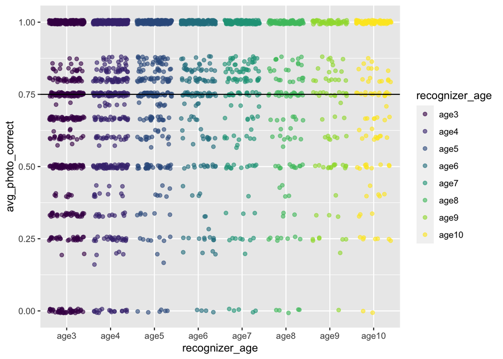

```r
# visualize these data by each age group
ggplot(photo_correct, aes(x=recognizer_age, y=avg_photo_correct, col=recognizer_age)) +
  geom_jitter(alpha=.6) +
  scale_color_viridis(discrete=TRUE) +
  geom_hline(yintercept=threshold)
```

```r
# make a list of the subjects who don't meet our threshold
bad_subs <- photo_correct %>%
  filter(avg_photo_correct < threshold) ## includes subjects who got 75% correct, excludes all those below
```

### Filter out subs who don’t meet photo correct threshold

```r
# filter bad subs
d <- d %>%
  filter(!sessionId %in% bad_subs$sessionId)

# check that we did this right
photo_trials_by_sub <- d %>%
  filter(producer_age == 'photo') %>%
  group_by(sessionId) %>%
  summarize(avg_correct = mean(correct_or_not))
# make sure this is true.
assert_that(sum(photo_trials_by_sub$avg_correct<threshold)==0)
```

```
## [1] TRUE
```

### Finally, filter kids that didn’t have valid trials on both photo/sketch trials

```r
cor_by_trial_type <- d %>%
  mutate(photo_or_not = (producer_age == 'photo')) %>%
  group_by(photo_or_not,sessionId) %>%
  summarize(count_cor = sum(correct_or_not), count_items = n(), avg_correct = count_cor / count_items)
only_one_type <- cor_by_trial_type %>%
  group_by(sessionId) %>%
  summarize(count_ids = n()) %>%
  filter(count_ids == 1)
# filter these subjects
d <- d %>%
  filter(!sessionId %in% only_one_type$sessionId)
```

### Calculate number of trials per kid (not adult) after these exclusions and report exclusions

```r
num_trials_per_kid <- d %>%
  # filter(!sessionId %in% adults$sessionId) %>% # exclude adults (prereg code, error)
  filter(recognizer_age != "adult") %>% # exclude adults
  group_by(sessionId) %>%
  summarize(max_trials = max(trial_num)) %>%
  summarize(average_trials = mean(max_trials))
num_kids_per_exp <- d %>%
  filter(recognizer_age != "adult") %>% # exclude adults
  group_by(exp,recognizer_age) %>%
  summarize(num_subs = length(unique(sessionId)))
##
```

First, we excluded children who started the game but did not complete more than 1 trial after the practice trials (N = 1068 participants) and the 238 adults who participated. We also excluded all trials with RTs slower than 10s or faster than 100ms, judging these to be off-task responses. Next, we excluded participants on the basis of their performance on practice and catch trials; given that these catch trials presented a very easy recognition task, we excluded participants who did not acheive at least 75% accuracy on these trials (N= 795). The remaining 1789 who met this criterion completed an average of 21.69 trials. On total, we analyzed 36615 trials where children recognized each others drawings.

### Exclusion rates in each age bin; see that we are mostly filtering out young kids not on task.

```r
bad_subs_descriptives <- orig_d %>%
  filter(sessionId %in% bad_subs$sessionId) %>%
  group_by(sessionId) %>%
  summarize(count_trials = n(), recognizer_age = recognizer_age[1]) %>%
  group_by(recognizer_age) %>%
  summarize(count_subs = n(), avg_trials = mean(count_trials))
kable(bad_subs_descriptives)
```

| recognizer_age | count_subs | avg_trials |
| --- | --- | --- |
| age10 | 46 | 19.19565 |
| age3 | 270 | 14.37778 |
| age4 | 180 | 16.18889 |
| age5 | 103 | 21.38835 |
| age6 | 60 | 20.16667 |
| age7 | 50 | 17.58000 |
| age8 | 49 | 17.34694 |
| age9 | 37 | 15.45946 |

### Calculate number of subs left in each age

```r
d %>%
  group_by(recognizer_age) %>%
  summarize(num_subs = length(unique(sessionId))) %>%
  kable()
```

| recognizer_age | num_subs |
| --- | --- |
| age3 | 329 |
| age4 | 408 |
| age5 | 301 |
| age6 | 227 |
| age7 | 188 |
| age8 | 131 |
| age9 | 84 |
| age10 | 121 |

## First set of descriptives

### How are recognizers doing on photo trials aross age? Looks pretty flat.

```r
by_recognizer_photo <- d %>%
  group_by(recognizer_age) %>%
  filter(producer_age == 'photo') %>%
  group_by(sessionId,recognizer_age) %>%
  summarize(indiv_photo_correct = mean(correct_or_not)) %>% # average first over individual participants
  group_by(recognizer_age) %>%
  multi_boot_standard(col = 'indiv_photo_correct')
```

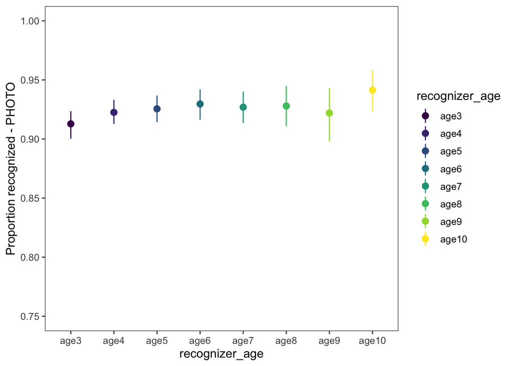

```r
by_recognizer_photo$recognizer_age <- factor(by_recognizer_photo$recognizer_age, levels = c('age2','age3','age4','age5','age6','age7','age8','age9','age10','adult'))

ggplot(by_recognizer_photo,aes(x=recognizer_age, y=mean, col = recognizer_age)) +
  geom_pointrange(aes(ymin = ci_lower, ymax = ci_upper)) +
  scale_color_viridis(discrete = "TRUE") +
  ylab('Proportion recognized - PHOTO') +
  ylim(.75,1) + # can't be lower than 75% correct or higher than 1
  theme_few()
```

### Look at overall recognition by recognizer age; looks like we should exclude 2 year-olds.

```r
by_recognizer_age <- d %>%
  filter(producer_age != 'photo') %>%
  group_by(sessionId, recognizer_age_numeric) %>%
  summarize(avg_correct = mean(correct_or_not), num_trials = n()) %>%
  filter(num_trials > 5) %>%
  group_by(recognizer_age_numeric) %>%
  multi_boot_standard(col = 'avg_correct')
by_each_recognizer <- d %>%
  group_by(sessionId,recognizer_age_numeric) %>%
  filter(producer_age != 'photo') %>%
  summarize(avg_correct = mean(correct_or_not), num_trials = n()) %>%
  filter(num_trials > 5)
```

# Figure 4A

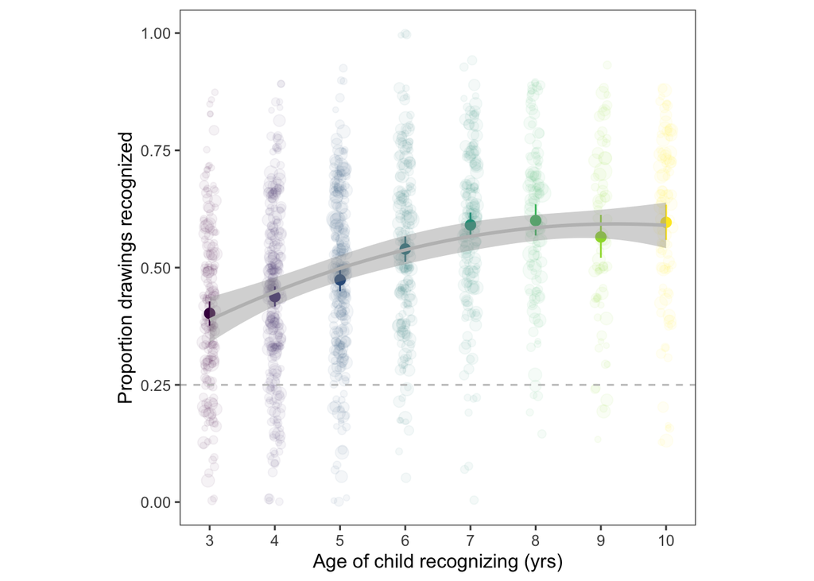

```r
base_size_chosen=12
ggplot(by_recognizer_age,aes(x=recognizer_age_numeric, y=mean, col = recognizer_age_numeric)) +
  theme_few(base_size = base_size_chosen) +
  geom_pointrange(aes(ymin = ci_lower, ymax = ci_upper)) +
  geom_jitter(data = by_each_recognizer, aes(x=recognizer_age_numeric, y=avg_correct, size=num_trials), alpha=.05, width=.1, height=.01) +
  scale_color_viridis(discrete = "FALSE") +
  scale_size_area(max_size = 5) +
  ylab('Proportion drawings recognized') +
  ylim(0, 1) +
  geom_hline(yintercept = .25, linetype = 'dashed', color='grey')  +
  geom_smooth(color = 'grey', span=10) +
  xlab('Age of child recognizing (yrs)') +
  theme(legend.position='none', aspect.ratio = 1) +
  # labs(title='Drawing recognition by age') +
  scale_x_continuous(breaks = seq(3,10,1))
```

```r
ggsave('figures/drawing_recognition_by_age_v2.pdf',width=3, height=3, units='in')
```

## filter recognition data to just kids and wrangle variables

```r
kids_sketches_d <- d %>%
  filter(producer_age != 'photo') %>% # don't look at photo trials
  filter(recognizer_age != 'age2') %>%  # or 2-yr-olds
  mutate(recognizer_age_numeric = as.numeric(str_split_fixed(recognizer_age,'age',2)[,2])) %>%
  mutate(recognizer_age_group = cut(recognizer_age_numeric, c(2.9, 4, 6, 8, 10.1), labels = c("3-4 yrs","5-6 yrs","7-8 yrs","9-10 yrs"))) %>%
  mutate(recognizer_age_group_numeric = cut(recognizer_age_numeric, c(2.9, 4, 6, 8, 10.1), labels=c(3,5,7,9))) %>%
  mutate(recognizer_age_group_numeric = as.numeric(recognizer_age_group_numeric))
```

### And wrangle sketch paths so can be joined with classification data outputs

```r
kids_sketches_d <- kids_sketches_d %>%
  mutate(sketch_path = as.factor(str_split_fixed(sketch_path,'/',2)[,2])) %>%
  mutate(sketch_path = as.factor(str_split_fixed(sketch_path,'.png',2)[,1]))
```

## Compute and plot recognition by sketch distinctiveness

We expect that the distintiveness of each drawing will be a major factor in how well it is recognized, and, further, that older children will be more sensitive to the presence of these distinctive features.

### Import classifications data (4-way classifications separetly for each run of recoggames)

```r
c_vehiclegame <- read.csv("compiled_classifications/classification-outputs-vehiclegame_C_0.1_460.csv") %>%
  as.tibble() %>%
  select(-X.1, -X) %>%
  mutate(denom = (airplane_prob + train_prob + boat_prob + car_prob) - target_label_prob) %>%
  mutate(log_odds = log(target_label_prob / denom)) %>% ## compute log odd probability
  mutate(exp='vehiclegame')

# now read it and join with other classifications
c_animalgame <- read.csv("compiled_classifications/classification-outputs-animalgame_C_0.1_560.csv") %>%
  as.tibble() %>%
  select(-X.1, -X) %>%
  mutate(denom = (dog_prob + fish_prob + rabbit_prob + bird_prob) - target_label_prob) %>%
  mutate(log_odds = log(target_label_prob / denom)) %>%
  mutate(exp='animalgame')

#
c_biganimalgame <- read.csv("compiled_classifications/classification-outputs-biganimalgame_C_0.1_600.csv") %>%
  as.tibble() %>%
  select(-X.1, -X) %>%
  mutate(denom = (bear_prob + sheep_prob + camel_prob + tiger_prob) - target_label_prob) %>%
  mutate(log_odds = log(target_label_prob / denom)) %>%
  mutate(exp='animalgame')


# now read it and join with other classifications
c <- read.csv("compiled_classifications/classification-outputs-objectgame_C_0.1_500.csv") %>%
  as.tibble() %>%
  select(-X.1, -X) %>%
  mutate(denom = (bottle_prob + lamp_prob + hat_prob + cup_prob) - target_label_prob) %>%
  mutate(log_odds = log(target_label_prob / denom)) %>%
  mutate(exp='objectgame') %>%
  full_join(c_vehiclegame) %>%
  full_join(c_animalgame) %>%
  full_join(c_biganimalgame) %>%
  mutate(sketch_path = paste0(target_label,'_','sketch_age',age,'_cdm_',session_id)) %>%
  mutate(sketch_path = as.factor(sketch_path))  %>%
  rename(model_correct_or_not = correct_or_not)
```

## Compute distincitveness bins (used for visualizations) join classifications & recognition data

```r
num_bins=10

## compute bins for distinctiveness
sketch_by_distinctiveness <- c %>%
  mutate(distinct_index = ntile(log_odds,num_bins)) %>% ## compute bins based on log odds over entire dataset
  select(sketch_path, distinct_index, log_odds, model_correct_or_not)

## join distinctiveness bins for each sketch in dataset
all_joined <- kids_sketches_d %>%
  left_join(sketch_by_distinctiveness) %>%
  filter(!is.na(model_correct_or_not))  # a few sketches in animalgame were accidentally included that should have been filtered (contained words, were scribbles and so don't have corresponding model classifications)
```

### Figure 4B: lot distinctivenss by age group interaction

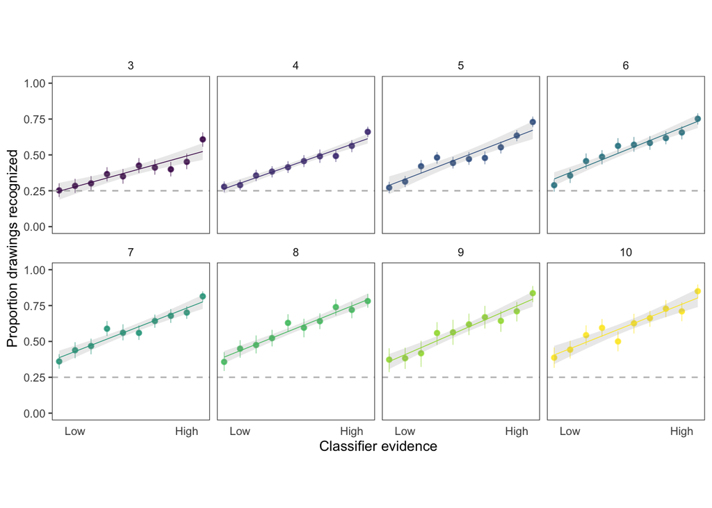

```r
## Panel B in ms figure
distinct_by_age <- all_joined %>%
  group_by(recognizer_age_numeric, distinct_index) %>%
  multi_boot_standard(col='correct_or_not') %>%
  group_by(distinct_index) %>%
  mutate(recognizer_age_name = paste0(as.character(recognizer_age_numeric), '-year-olds'))

 ggplot(distinct_by_age, aes(x=distinct_index, y=mean, col=as.factor(recognizer_age_numeric))) +
  geom_pointrange(aes(ymin = ci_lower, ymax = ci_upper), alpha=.8, size=.2) +
  geom_smooth(alpha=.2, span=4, method='lm', size=.25) +
  facet_wrap(~recognizer_age_numeric, nrow=2) +
  theme_few(base_size = 10) +
  xlab('Classifier evidence') +
  ylab('Proportion drawings recognized') +
  theme(legend.position='none') +
  scale_color_viridis(discrete=TRUE) +
  scale_x_continuous(
    breaks=c(2,9),
    labels=c(' Low ',' High ')
        ) +
  theme(axis.ticks.x=element_blank(), aspect.ratio=1) +
  geom_hline(yintercept=.25, linetype='dashed',color='grey') +
  ylim(0,1)
```

```r
ggsave('figures/DistinctByAge.pdf', height=3,  units='in')
```

# Inferential statistics

### Examine how distinctivenss vs age group interact in glmer

```r
set.seed(123) # for reproducibility

model_glmer <- glmer(correct_or_not ~ scale(log_odds)*scale(recognizer_age_numeric) + (scale(log_odds)|intended_category) + (1|sessionId),  data = all_joined, family='binomial')
out = summary(model_glmer)

round(out$coefficients,3)
```

```
##                                               Estimate Std. Error z value
## (Intercept)                                      0.050      0.121   0.412
## scale(log_odds)                                  0.477      0.046  10.405
## scale(recognizer_age_numeric)                    0.317      0.019  16.776
## scale(log_odds):scale(recognizer_age_numeric)    0.062      0.014   4.246
##                                               Pr(>|z|)
## (Intercept)                                       0.68
## scale(log_odds)                                   0.00
## scale(recognizer_age_numeric)                     0.00
## scale(log_odds):scale(recognizer_age_numeric)     0.00
```

```r
xtable::xtable(summary(out)$coef, digits=3, caption = "Model coefficients of a GLMM predicting visual recognition performance as a function of recognizer age and visual 'distinctiveness' (i.e. log-odds probability of selecting the correct label in logistic regression based on visual features, see Methods).")
```

```
## % latex table generated in R 3.6.1 by xtable 1.8-4 package
## % Tue Mar 30 16:23:16 2021
## \begin{table}[ht]
## \centering
## \begin{tabular}{rrrrr}
##   \hline
##  & Estimate & Std. Error & z value & Pr($>$$|$z$|$) \\
##   \hline
## (Intercept) & 0.050 & 0.121 & 0.412 & 0.680 \\
##   scale(log\_odds) & 0.477 & 0.046 & 10.405 & 0.000 \\
##   scale(recognizer\_age\_numeric) & 0.317 & 0.019 & 16.776 & 0.000 \\
##   scale(log\_odds):scale(recognizer\_age\_numeric) & 0.062 & 0.014 & 4.246 & 0.000 \\
##    \hline
## \end{tabular}
## \caption{Model coefficients of a GLMM predicting visual recognition performance as a function of recognizer age and visual 'distinctiveness' (i.e. log-odds probability of selecting the correct label in logistic regression based on visual features, see Methods).}
## \end{table}
```

# Supplemental: Visualize model fits by age

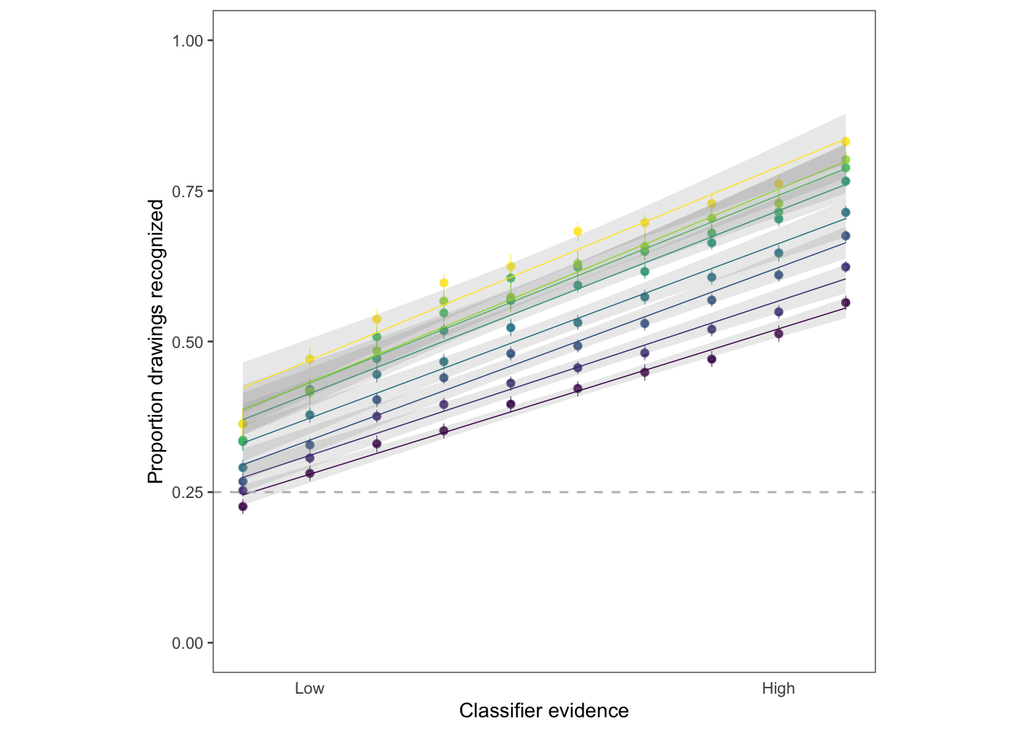

```r
predicted_vals = predict(model_glmer, all_joined, type='response')
all_joined_with_predictions <- all_joined
all_joined_with_predictions$prediction = predicted_vals

distinct_by_age_model_fits <- all_joined_with_predictions %>%
  group_by(recognizer_age_numeric, distinct_index) %>%
  multi_boot_standard(col='prediction') %>%
  group_by(distinct_index) %>%
  mutate(recognizer_age_name = paste0(as.character(recognizer_age_numeric), '-year-olds'))

 ggplot(distinct_by_age_model_fits, aes(x=distinct_index, y=mean, col=as.factor(recognizer_age_numeric))) +
  geom_pointrange(aes(ymin = ci_lower, ymax = ci_upper), alpha=.8, size=.2) +
  geom_smooth(alpha=.2, span=4, method='lm', size=.25) +
  # facet_wrap(~recognizer_age_numeric, nrow=2) +
  theme_few(base_size = 10) +
  xlab('Classifier evidence') +
  ylab('Proportion drawings recognized') +
  theme(legend.position='none') +
  scale_color_viridis(discrete=TRUE) +
  scale_x_continuous(
    breaks=c(2,9),
    labels=c(' Low ',' High ')
        ) +
  theme(axis.ticks.x=element_blank(), aspect.ratio=1) +
  geom_hline(yintercept=.25, linetype='dashed',color='grey') +
  ylim(0,1)
```